# 项目：基于线性回归的房价预测

第十四组：

P12314008 刘昊辰

P12314012 张嘉诚

P12314016 罗天屹

P12314080 丁梓翔

## 分析目标

基于已有的房屋销售价格，以及有关该房屋的属性，进行线性回归分析，从而利用得到的线性回归模型，能对以下未知售价的房屋根据属性进行价格预测：

## 模块一：数据处理与数据分析

### 读取数据：把数据导入并粗略查看

```python
import numpy as np
import pandas as pd
```

```python
df1 = pd.read_csv("house_price.csv")
df1.head()
```

|  | price | area | bedrooms | bathrooms | stories | mainroad | guestroom | basement | hotwaterheating | airconditioning | parking | prefarea | furnishingstatus |
| --- | --- | --- | --- | --- | --- | --- | --- | --- | --- | --- | --- | --- | --- |
| 0 | 13300000 | 7420 | 4 | 2 | 3 | yes | no | no | no | yes | 2 | yes | furnished |
| 1 | 12250000 | 8960 | 4 | 4 | 4 | yes | no | no | no | yes | 3 | no | furnished |
| 2 | 12250000 | 9960 | 3 | 2 | 2 | yes | no | yes | no | no | 2 | yes | semi-furnished |
| 3 | 12215000 | 7500 | 4 | 2 | 2 | yes | no | yes | no | yes | 3 | yes | furnished |
| 4 | 11410000 | 7420 | 4 | 1 | 2 | yes | yes | yes | no | yes | 2 | no | furnished |

```python
df1.tail()
```

|  | price | area | bedrooms | bathrooms | stories | mainroad | guestroom | basement | hotwaterheating | airconditioning | parking | prefarea | furnishingstatus |
| --- | --- | --- | --- | --- | --- | --- | --- | --- | --- | --- | --- | --- | --- |
| 540 | 1820000 | 3000 | 2 | 1 | 1 | yes | no | yes | no | no | 2 | no | unfurnished |
| 541 | 1767150 | 2400 | 3 | 1 | 1 | no | no | no | no | no | 0 | no | semi-furnished |
| 542 | 1750000 | 3620 | 2 | 1 | 1 | yes | no | no | no | no | 0 | no | unfurnished |
| 543 | 1750000 | 2910 | 3 | 1 | 1 | no | no | no | no | no | 0 | no | furnished |
| 544 | 1750000 | 3850 | 3 | 1 | 2 | yes | no | no | no | no | 0 | no | unfurnished |

查看数据集可知，此数据集记录了超过五百栋房屋的交易价格，以及房屋的相关属性信息，包括房屋价格、面积、卧室数、厕所数、楼层数、是否位于主路、是否有客房、是否有地下室、是否有热水器、是否有空调、车库能放几辆车、是否位于城市首选社区、装修状态

### 评估数据：整体评估数据干净整洁or脏乱

**评估数据丢失**

```python
df1.sample(10)
```

|  | price | area | bedrooms | bathrooms | stories | mainroad | guestroom | basement | hotwaterheating | airconditioning | parking | prefarea | furnishingstatus |
| --- | --- | --- | --- | --- | --- | --- | --- | --- | --- | --- | --- | --- | --- |
| 127 | 5880000 | 6500 | 3 | 2 | 3 | yes | no | no | no | yes | 0 | no | unfurnished |
| 7 | 10150000 | 16200 | 5 | 3 | 2 | yes | no | no | no | no | 0 | no | unfurnished |
| 336 | 3920000 | 8080 | 3 | 1 | 1 | yes | no | no | no | yes | 2 | no | semi-furnished |
| 10 | 9800000 | 13200 | 3 | 1 | 2 | yes | no | yes | no | yes | 2 | yes | furnished |
| 2 | 12250000 | 9960 | 3 | 2 | 2 | yes | no | yes | no | no | 2 | yes | semi-furnished |
| 500 | 2660000 | 2800 | 3 | 1 | 1 | yes | no | no | no | no | 0 | no | unfurnished |
| 168 | 5250000 | 4260 | 4 | 1 | 2 | yes | no | yes | no | yes | 0 | no | furnished |
| 219 | 4795000 | 7000 | 3 | 1 | 2 | yes | no | yes | no | no | 0 | no | unfurnished |
| 391 | 3500000 | 3036 | 3 | 1 | 2 | yes | no | yes | no | no | 0 | no | semi-furnished |
| 316 | 4060000 | 5900 | 4 | 2 | 2 | no | no | yes | no | no | 1 | no | unfurnished |

```python
df1.info()
```

```
<class 'pandas.core.frame.DataFrame'>
RangeIndex: 545 entries, 0 to 544
Data columns (total 13 columns):
 #   Column            Non-Null Count  Dtype
---  ------            --------------  -----
 0   price             545 non-null    int64
 1   area              545 non-null    int64
 2   bedrooms          545 non-null    int64
 3   bathrooms         545 non-null    int64
 4   stories           545 non-null    int64
 5   mainroad          545 non-null    object
 6   guestroom         545 non-null    object
 7   basement          545 non-null    object
 8   hotwaterheating   545 non-null    object
 9   airconditioning   545 non-null    object
 10  parking           545 non-null    int64
 11  prefarea          545 non-null    object
 12  furnishingstatus  545 non-null    object
dtypes: int64(6), object(7)
memory usage: 55.5+ KB
```

```python
df1.isnull().sum()
```

```
price               0
area                0
bedrooms            0
bathrooms           0
stories             0
mainroad            0
guestroom           0
basement            0
hotwaterheating     0
airconditioning     0
parking             0
prefarea            0
furnishingstatus    0
dtype: int64
```

不存在数据丢失

该数据每列是一个变量，每行是一个观察值，每个单元格是一个值,是整洁的数据

**评估重复数据**

```python
df1.duplicated()
```

```
0      False
1      False
2      False
3      False
4      False
       ...
540    False
541    False
542    False
543    False
544    False
Length: 545, dtype: bool
```

无完全重复数据

**评估不一致数据**

**评估无效或者错误数据：排除离谱的数据**

```python
df1.sample(10)
```

|  | price | area | bedrooms | bathrooms | stories | mainroad | guestroom | basement | hotwaterheating | airconditioning | parking | prefarea | furnishingstatus |
| --- | --- | --- | --- | --- | --- | --- | --- | --- | --- | --- | --- | --- | --- |
| 189 | 5040000 | 3540 | 2 | 1 | 1 | no | yes | yes | no | no | 0 | no | semi-furnished |
| 39 | 7910000 | 6000 | 4 | 2 | 4 | yes | no | no | no | yes | 1 | no | semi-furnished |
| 27 | 8400000 | 8875 | 3 | 1 | 1 | yes | no | no | no | no | 1 | no | semi-furnished |
| 381 | 3605000 | 4000 | 2 | 1 | 1 | yes | no | no | no | no | 0 | yes | semi-furnished |
| 348 | 3815000 | 3150 | 2 | 2 | 1 | no | no | yes | no | no | 0 | no | semi-furnished |
| 81 | 6615000 | 4000 | 3 | 2 | 2 | yes | no | yes | no | yes | 1 | no | semi-furnished |
| 22 | 8645000 | 8050 | 3 | 1 | 1 | yes | yes | yes | no | yes | 1 | no | furnished |
| 215 | 4830000 | 4160 | 3 | 1 | 3 | yes | no | no | no | no | 0 | no | unfurnished |
| 102 | 6195000 | 5500 | 3 | 2 | 4 | yes | yes | no | no | yes | 1 | no | semi-furnished |
| 154 | 5530000 | 3650 | 3 | 2 | 2 | yes | no | no | no | no | 2 | no | semi-furnished |

```python
df1.value_counts("mainroad")
```

```
mainroad
yes    468
no      77
Name: count, dtype: int64
```

```python
df1.value_counts("guestroom")
```

```
guestroom
no     448
yes     97
Name: count, dtype: int64
```

```python
df1.value_counts("basement")
```

```
basement
no     354
yes    191
Name: count, dtype: int64
```

```python
df1.value_counts("hotwaterheating")
```

```
hotwaterheating
no     520
yes     25
Name: count, dtype: int64
```

```python
df1.value_counts("airconditioning")
```

```
airconditioning
no     373
yes    172
Name: count, dtype: int64
```

```python
df1.value_counts("prefarea")
```

```
prefarea
no     417
yes    128
Name: count, dtype: int64
```

```python
df1.value_counts("furnishingstatus")
```

```
furnishingstatus
semi-furnished    227
unfurnished       178
furnished         140
Name: count, dtype: int64
```

装修程度这里没有错误数据

```python
df1.sort_values("price")
```

|  | price | area | bedrooms | bathrooms | stories | mainroad | guestroom | basement | hotwaterheating | airconditioning | parking | prefarea | furnishingstatus |
| --- | --- | --- | --- | --- | --- | --- | --- | --- | --- | --- | --- | --- | --- |
| 544 | 1750000 | 3850 | 3 | 1 | 2 | yes | no | no | no | no | 0 | no | unfurnished |
| 543 | 1750000 | 2910 | 3 | 1 | 1 | no | no | no | no | no | 0 | no | furnished |
| 542 | 1750000 | 3620 | 2 | 1 | 1 | yes | no | no | no | no | 0 | no | unfurnished |
| 541 | 1767150 | 2400 | 3 | 1 | 1 | no | no | no | no | no | 0 | no | semi-furnished |
| 540 | 1820000 | 3000 | 2 | 1 | 1 | yes | no | yes | no | no | 2 | no | unfurnished |
| ... | ... | ... | ... | ... | ... | ... | ... | ... | ... | ... | ... | ... | ... |
| 4 | 11410000 | 7420 | 4 | 1 | 2 | yes | yes | yes | no | yes | 2 | no | furnished |
| 3 | 12215000 | 7500 | 4 | 2 | 2 | yes | no | yes | no | yes | 3 | yes | furnished |
| 2 | 12250000 | 9960 | 3 | 2 | 2 | yes | no | yes | no | no | 2 | yes | semi-furnished |
| 1 | 12250000 | 8960 | 4 | 4 | 4 | yes | no | no | no | yes | 3 | no | furnished |
| 0 | 13300000 | 7420 | 4 | 2 | 3 | yes | no | no | no | yes | 2 | yes | furnished |

545 rows × 13 columns

房价最大一千多万，最小一百多万，合理

```python
df1.sort_values("area")
```

|  | price | area | bedrooms | bathrooms | stories | mainroad | guestroom | basement | hotwaterheating | airconditioning | parking | prefarea | furnishingstatus |
| --- | --- | --- | --- | --- | --- | --- | --- | --- | --- | --- | --- | --- | --- |
| 449 | 3150000 | 1650 | 3 | 1 | 2 | no | no | yes | no | no | 0 | no | unfurnished |
| 537 | 1890000 | 1700 | 3 | 1 | 2 | yes | no | no | no | no | 0 | no | unfurnished |
| 527 | 2275000 | 1836 | 2 | 1 | 1 | no | no | yes | no | no | 0 | no | semi-furnished |
| 271 | 4340000 | 1905 | 5 | 1 | 2 | no | no | yes | no | no | 0 | no | semi-furnished |
| 413 | 3430000 | 1950 | 3 | 2 | 2 | yes | no | yes | no | no | 0 | yes | unfurnished |
| ... | ... | ... | ... | ... | ... | ... | ... | ... | ... | ... | ... | ... | ... |
| 403 | 3500000 | 12944 | 3 | 1 | 1 | yes | no | no | no | no | 0 | no | unfurnished |
| 66 | 6930000 | 13200 | 2 | 1 | 1 | yes | no | yes | yes | no | 1 | no | furnished |
| 10 | 9800000 | 13200 | 3 | 1 | 2 | yes | no | yes | no | yes | 2 | yes | furnished |
| 125 | 5943000 | 15600 | 3 | 1 | 1 | yes | no | no | no | yes | 2 | no | semi-furnished |
| 7 | 10150000 | 16200 | 5 | 3 | 2 | yes | no | no | no | no | 0 | no | unfurnished |

545 rows × 13 columns

面积最大16200平方英尺，最小1650英尺，合理

```python
df1.describe()
```

|  | price | area | bedrooms | bathrooms | stories | parking |
| --- | --- | --- | --- | --- | --- | --- |
| count | 5.450000e+02 | 545.000000 | 545.000000 | 545.000000 | 545.000000 | 545.000000 |
| mean | 4.766729e+06 | 5150.541284 | 2.965138 | 1.286239 | 1.805505 | 0.693578 |
| std | 1.870440e+06 | 2170.141023 | 0.738064 | 0.502470 | 0.867492 | 0.861586 |
| min | 1.750000e+06 | 1650.000000 | 1.000000 | 1.000000 | 1.000000 | 0.000000 |
| 25% | 3.430000e+06 | 3600.000000 | 2.000000 | 1.000000 | 1.000000 | 0.000000 |
| 50% | 4.340000e+06 | 4600.000000 | 3.000000 | 1.000000 | 2.000000 | 0.000000 |
| 75% | 5.740000e+06 | 6360.000000 | 3.000000 | 2.000000 | 2.000000 | 1.000000 |
| max | 1.330000e+07 | 16200.000000 | 6.000000 | 4.000000 | 4.000000 | 3.000000 |

该数据的数值部分是合理的，没有特别离谱反常识的地方，综合来看，数据既干净又整洁

### 清洗数据

根据前面的评估，数据既干净又整洁，但是由于全是英文，对中国人来说读起来不是很方便，所以要对表格进行调整

**重命名列名**

```python
df2 = df1.rename(columns = {"price":"价格","area":"面积","bedrooms":"卧室数量","bathrooms":"浴室数量","stories":"楼层数","parking":"车库数量"
                      ,"mainroad":"是否位于主干道","guestroom":"有无客房","basement":"有无地下室","hotwaterheating":"是否有热水器",
                      "airconditioning":"有无空调","prefarea":"是否为城市首选社区","furnishingstatus":"装修状态"})
df2
```

|  | 价格 | 面积 | 卧室数量 | 浴室数量 | 楼层数 | 是否位于主干道 | 有无客房 | 有无地下室 | 是否有热水器 | 有无空调 | 车库数量 | 是否为城市首选社区 | 装修状态 |
| --- | --- | --- | --- | --- | --- | --- | --- | --- | --- | --- | --- | --- | --- |
| 0 | 13300000 | 7420 | 4 | 2 | 3 | yes | no | no | no | yes | 2 | yes | furnished |
| 1 | 12250000 | 8960 | 4 | 4 | 4 | yes | no | no | no | yes | 3 | no | furnished |
| 2 | 12250000 | 9960 | 3 | 2 | 2 | yes | no | yes | no | no | 2 | yes | semi-furnished |
| 3 | 12215000 | 7500 | 4 | 2 | 2 | yes | no | yes | no | yes | 3 | yes | furnished |
| 4 | 11410000 | 7420 | 4 | 1 | 2 | yes | yes | yes | no | yes | 2 | no | furnished |
| ... | ... | ... | ... | ... | ... | ... | ... | ... | ... | ... | ... | ... | ... |
| 540 | 1820000 | 3000 | 2 | 1 | 1 | yes | no | yes | no | no | 2 | no | unfurnished |
| 541 | 1767150 | 2400 | 3 | 1 | 1 | no | no | no | no | no | 0 | no | semi-furnished |
| 542 | 1750000 | 3620 | 2 | 1 | 1 | yes | no | no | no | no | 0 | no | unfurnished |
| 543 | 1750000 | 2910 | 3 | 1 | 1 | no | no | no | no | no | 0 | no | furnished |
| 544 | 1750000 | 3850 | 3 | 1 | 2 | yes | no | no | no | no | 0 | no | unfurnished |

545 rows × 13 columns

**对英文值进行替换**

```python
df3 = df2.replace({"furnished":"精装","semi-furnished":"简装","unfurnished":"毛坯"})
df3
```

|  | 价格 | 面积 | 卧室数量 | 浴室数量 | 楼层数 | 是否位于主干道 | 有无客房 | 有无地下室 | 是否有热水器 | 有无空调 | 车库数量 | 是否为城市首选社区 | 装修状态 |
| --- | --- | --- | --- | --- | --- | --- | --- | --- | --- | --- | --- | --- | --- |
| 0 | 13300000 | 7420 | 4 | 2 | 3 | yes | no | no | no | yes | 2 | yes | 精装 |
| 1 | 12250000 | 8960 | 4 | 4 | 4 | yes | no | no | no | yes | 3 | no | 精装 |
| 2 | 12250000 | 9960 | 3 | 2 | 2 | yes | no | yes | no | no | 2 | yes | 简装 |
| 3 | 12215000 | 7500 | 4 | 2 | 2 | yes | no | yes | no | yes | 3 | yes | 精装 |
| 4 | 11410000 | 7420 | 4 | 1 | 2 | yes | yes | yes | no | yes | 2 | no | 精装 |
| ... | ... | ... | ... | ... | ... | ... | ... | ... | ... | ... | ... | ... | ... |
| 540 | 1820000 | 3000 | 2 | 1 | 1 | yes | no | yes | no | no | 2 | no | 毛坯 |
| 541 | 1767150 | 2400 | 3 | 1 | 1 | no | no | no | no | no | 0 | no | 简装 |
| 542 | 1750000 | 3620 | 2 | 1 | 1 | yes | no | no | no | no | 0 | no | 毛坯 |
| 543 | 1750000 | 2910 | 3 | 1 | 1 | no | no | no | no | no | 0 | no | 精装 |
| 544 | 1750000 | 3850 | 3 | 1 | 2 | yes | no | no | no | no | 0 | no | 毛坯 |

545 rows × 13 columns

**把平方英尺换成平方米，公式$$平方米 = 0.0929 * 平方英尺$$**

```python
df3["面积"] = df3["面积"] * 0.0929
df3
```

|  | 价格 | 面积 | 卧室数量 | 浴室数量 | 楼层数 | 是否位于主干道 | 有无客房 | 有无地下室 | 是否有热水器 | 有无空调 | 车库数量 | 是否为城市首选社区 | 装修状态 |
| --- | --- | --- | --- | --- | --- | --- | --- | --- | --- | --- | --- | --- | --- |
| 0 | 13300000 | 689.318 | 4 | 2 | 3 | yes | no | no | no | yes | 2 | yes | 精装 |
| 1 | 12250000 | 832.384 | 4 | 4 | 4 | yes | no | no | no | yes | 3 | no | 精装 |
| 2 | 12250000 | 925.284 | 3 | 2 | 2 | yes | no | yes | no | no | 2 | yes | 简装 |
| 3 | 12215000 | 696.750 | 4 | 2 | 2 | yes | no | yes | no | yes | 3 | yes | 精装 |
| 4 | 11410000 | 689.318 | 4 | 1 | 2 | yes | yes | yes | no | yes | 2 | no | 精装 |
| ... | ... | ... | ... | ... | ... | ... | ... | ... | ... | ... | ... | ... | ... |
| 540 | 1820000 | 278.700 | 2 | 1 | 1 | yes | no | yes | no | no | 2 | no | 毛坯 |
| 541 | 1767150 | 222.960 | 3 | 1 | 1 | no | no | no | no | no | 0 | no | 简装 |
| 542 | 1750000 | 336.298 | 2 | 1 | 1 | yes | no | no | no | no | 0 | no | 毛坯 |
| 543 | 1750000 | 270.339 | 3 | 1 | 1 | no | no | no | no | no | 0 | no | 精装 |
| 544 | 1750000 | 357.665 | 3 | 1 | 2 | yes | no | no | no | no | 0 | no | 毛坯 |

545 rows × 13 columns

```python
df3.describe()
```

|  | 价格 | 面积 | 卧室数量 | 浴室数量 | 楼层数 | 车库数量 |
| --- | --- | --- | --- | --- | --- | --- |
| count | 5.450000e+02 | 545.000000 | 545.000000 | 545.000000 | 545.000000 | 545.000000 |
| mean | 4.766729e+06 | 478.485285 | 2.965138 | 1.286239 | 1.805505 | 0.693578 |
| std | 1.870440e+06 | 201.606101 | 0.738064 | 0.502470 | 0.867492 | 0.861586 |
| min | 1.750000e+06 | 153.285000 | 1.000000 | 1.000000 | 1.000000 | 0.000000 |
| 25% | 3.430000e+06 | 334.440000 | 2.000000 | 1.000000 | 1.000000 | 0.000000 |
| 50% | 4.340000e+06 | 427.340000 | 3.000000 | 1.000000 | 2.000000 | 0.000000 |
| 75% | 5.740000e+06 | 590.844000 | 3.000000 | 2.000000 | 2.000000 | 1.000000 |
| max | 1.330000e+07 | 1504.980000 | 6.000000 | 4.000000 | 4.000000 | 3.000000 |

**对值的类型进行转换**

```python
df4 = df3.copy()
df4
```

|  | 价格 | 面积 | 卧室数量 | 浴室数量 | 楼层数 | 是否位于主干道 | 有无客房 | 有无地下室 | 是否有热水器 | 有无空调 | 车库数量 | 是否为城市首选社区 | 装修状态 |
| --- | --- | --- | --- | --- | --- | --- | --- | --- | --- | --- | --- | --- | --- |
| 0 | 13300000 | 689.318 | 4 | 2 | 3 | yes | no | no | no | yes | 2 | yes | 精装 |
| 1 | 12250000 | 832.384 | 4 | 4 | 4 | yes | no | no | no | yes | 3 | no | 精装 |
| 2 | 12250000 | 925.284 | 3 | 2 | 2 | yes | no | yes | no | no | 2 | yes | 简装 |
| 3 | 12215000 | 696.750 | 4 | 2 | 2 | yes | no | yes | no | yes | 3 | yes | 精装 |
| 4 | 11410000 | 689.318 | 4 | 1 | 2 | yes | yes | yes | no | yes | 2 | no | 精装 |
| ... | ... | ... | ... | ... | ... | ... | ... | ... | ... | ... | ... | ... | ... |
| 540 | 1820000 | 278.700 | 2 | 1 | 1 | yes | no | yes | no | no | 2 | no | 毛坯 |
| 541 | 1767150 | 222.960 | 3 | 1 | 1 | no | no | no | no | no | 0 | no | 简装 |
| 542 | 1750000 | 336.298 | 2 | 1 | 1 | yes | no | no | no | no | 0 | no | 毛坯 |
| 543 | 1750000 | 270.339 | 3 | 1 | 1 | no | no | no | no | no | 0 | no | 精装 |
| 544 | 1750000 | 357.665 | 3 | 1 | 2 | yes | no | no | no | no | 0 | no | 毛坯 |

545 rows × 13 columns

```python
df4["是否位于主干道"] = df4["是否位于主干道"].astype("category")
df4["有无客房"] = df4["有无客房"].astype("category")
df4["有无地下室"] = df4["有无地下室"].astype("category")
df4["是否有热水器"] = df4["是否有热水器"].astype("category")
df4["有无空调"] = df4["有无空调"].astype("category")
df4["是否为城市首选社区"] = df4["是否为城市首选社区"].astype("category")
df4["装修状态"] = df4["装修状态"].astype("category")
df4
```

|  | 价格 | 面积 | 卧室数量 | 浴室数量 | 楼层数 | 是否位于主干道 | 有无客房 | 有无地下室 | 是否有热水器 | 有无空调 | 车库数量 | 是否为城市首选社区 | 装修状态 |
| --- | --- | --- | --- | --- | --- | --- | --- | --- | --- | --- | --- | --- | --- |
| 0 | 13300000 | 689.318 | 4 | 2 | 3 | yes | no | no | no | yes | 2 | yes | 精装 |
| 1 | 12250000 | 832.384 | 4 | 4 | 4 | yes | no | no | no | yes | 3 | no | 精装 |
| 2 | 12250000 | 925.284 | 3 | 2 | 2 | yes | no | yes | no | no | 2 | yes | 简装 |
| 3 | 12215000 | 696.750 | 4 | 2 | 2 | yes | no | yes | no | yes | 3 | yes | 精装 |
| 4 | 11410000 | 689.318 | 4 | 1 | 2 | yes | yes | yes | no | yes | 2 | no | 精装 |
| ... | ... | ... | ... | ... | ... | ... | ... | ... | ... | ... | ... | ... | ... |
| 540 | 1820000 | 278.700 | 2 | 1 | 1 | yes | no | yes | no | no | 2 | no | 毛坯 |
| 541 | 1767150 | 222.960 | 3 | 1 | 1 | no | no | no | no | no | 0 | no | 简装 |
| 542 | 1750000 | 336.298 | 2 | 1 | 1 | yes | no | no | no | no | 0 | no | 毛坯 |
| 543 | 1750000 | 270.339 | 3 | 1 | 1 | no | no | no | no | no | 0 | no | 精装 |
| 544 | 1750000 | 357.665 | 3 | 1 | 2 | yes | no | no | no | no | 0 | no | 毛坯 |

545 rows × 13 columns

```python
df4.info()
```

```
<class 'pandas.core.frame.DataFrame'>
RangeIndex: 545 entries, 0 to 544
Data columns (total 13 columns):
 #   Column     Non-Null Count  Dtype
---  ------     --------------  -----
 0   价格         545 non-null    int64
 1   面积         545 non-null    float64
 2   卧室数量       545 non-null    int64
 3   浴室数量       545 non-null    int64
 4   楼层数        545 non-null    int64
 5   是否位于主干道    545 non-null    category
 6   有无客房       545 non-null    category
 7   有无地下室      545 non-null    category
 8   是否有热水器     545 non-null    category
 9   有无空调       545 non-null    category
 10  车库数量       545 non-null    int64
 11  是否为城市首选社区  545 non-null    category
 12  装修状态       545 non-null    category
dtypes: category(7), float64(1), int64(5)
memory usage: 30.3 KB
```

## 模块二：可视化数据分析

### 探索数据（探索相关性）

导入可视化数据库

```python
import matplotlib.pyplot as plt
import seaborn as sns
```

```python
# 设置图表色盘为"pastel"
sns.set_palette("pastel")
#设置全局字体参数
plt.rcParams['font.sans-serif'] = ['SimHei']
```

**房价分布**

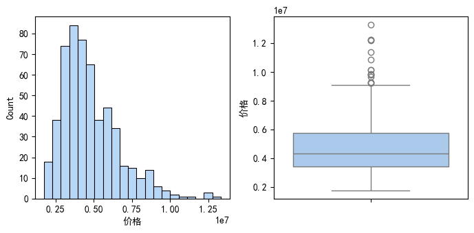

```python
plt.rcParams["figure.figsize"] = [7.00, 3.50]
plt.rcParams["figure.autolayout"] = True
figure, axes = plt.subplots(1,2)
sns.histplot(df4, x="价格", ax=axes[0])
sns.boxplot(df4, y="价格", ax=axes[1])
plt.show()
```

房价呈右偏态分布，说明数据集中的大多数房子价格中等，但有一些价格很高的极端值，使得均值被拉高。

**面积分布**

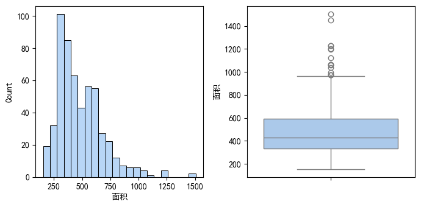

```python
figure, axes = plt.subplots(1,2)
sns.histplot(df4, x="面积", ax=axes[0])
sns.boxplot(df4, y="面积", ax=axes[1])
plt.show()
```

面积的分布与房价相似，也呈右偏态分布。

**房价与面积的关系**

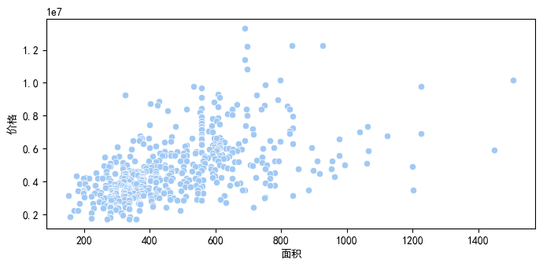

```python
sns.scatterplot(df4, x="面积", y="价格")
plt.show()
```

从散点图来看，能大致看出一些正相关关系，但关系的强度需要后续通过计算相关性来得到。

**卧室数与房价**

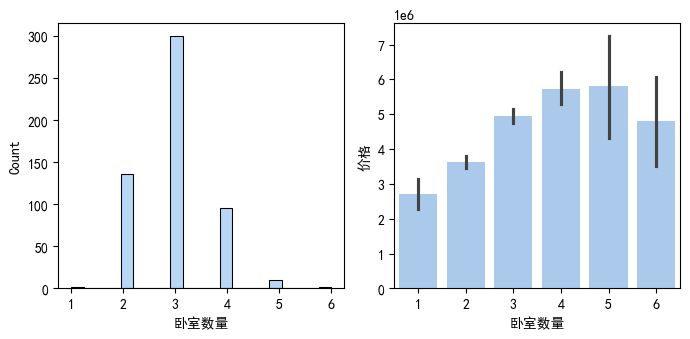

```python
figure, axes = plt.subplots(1,2)
sns.histplot(df4, x="卧室数量", ax=axes[0])
sns.barplot(df4, x="卧室数量" , y="价格", ax=axes[1])
plt.show()
```

此数据集中房子的卧室数范围为1-6个，其中大多房子有2-4个。

从平均房价与卧室数之间的柱状图来看，当卧室数小于5个时，卧室数多的房子价格也相应高，但一旦多于5个，房价并不一定相应更高

**浴室数与房价**

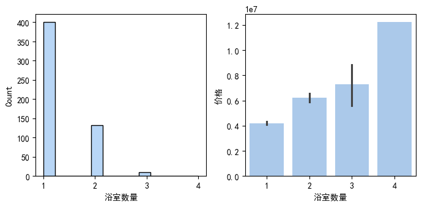

```python
figure, axes = plt.subplots(1,2)
sns.histplot(df4, x="浴室数量", ax = axes[0])
sns.barplot(df4, x="浴室数量", y = "价格", ax=axes[1])
plt.show()
```

数据集中房子洗手间数量最少1个，最多4个，其中为1个的数量最多。

从平均房价与洗手间数之间的柱状图来看，洗手间多的房子价格也相应高。

**楼层数与房价**

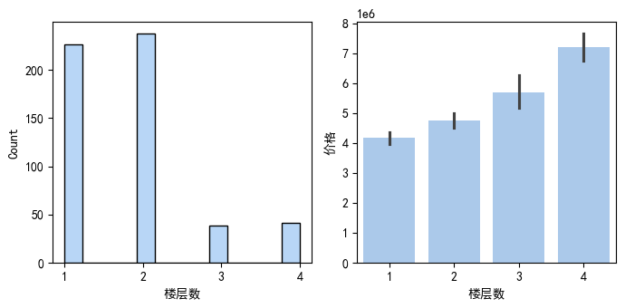

```python
figure, axes = plt.subplots(1, 2)
sns.histplot(df4, x='楼层数', ax=axes[0])
sns.barplot(df4, x='楼层数', y='价格', ax=axes[1])
plt.show()
```

此数据集中房子的楼层数范围为1-4层，其中大多房子有1层或2层。

从平均房价与楼层数之间的柱状图来看，楼层多的房子价格也相应高。

**车库数与房价**

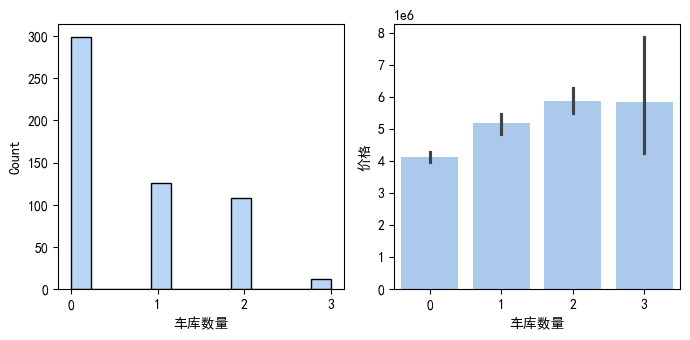

```python
figure, axes = plt.subplots(1, 2)
sns.histplot(df4, x='车库数量', ax=axes[0])
sns.barplot(df4, x='车库数量', y='价格', ax=axes[1])
plt.show()
```

**是否在主路与房价**

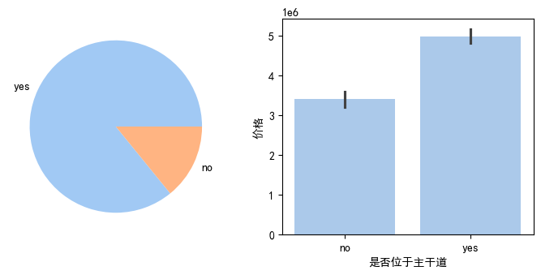

```python
figure, axes = plt.subplots(1,2)
mainroad_count = df4["是否位于主干道"].value_counts()
mainroad_label =mainroad_count.index
axes[0].pie(mainroad_count, labels=mainroad_label)
sns.barplot(df4, x="是否位于主干道", y="价格", ax=axes[1])
plt.show()
```

此数据集中房子大多数位于主路。

**是否有客房与房价**

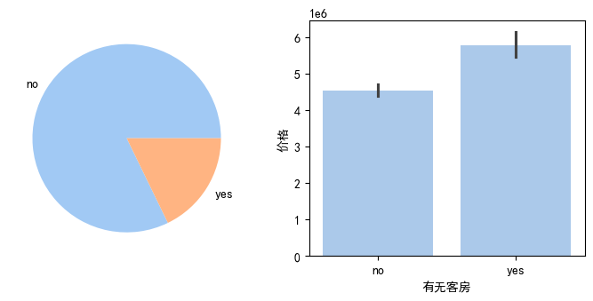

```python
figure, axes = plt.subplots(1, 2)
guestroom_count = df4['有无客房'].value_counts()
guestroom_label = guestroom_count.index
axes[0].pie(guestroom_count, labels=guestroom_label)
sns.barplot(df4, x='有无客房', y='价格', ax=axes[1])
plt.show()
```

此数据集中房子大部分没有客人房。

**是否有地下室与房价**

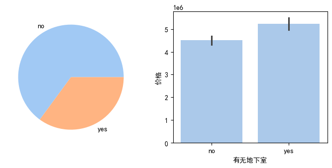

```python
figure, axes = plt.subplots(1, 2)
basement_count = df4["有无地下室"].value_counts()
basement_label = basement_count.index
axes[0].pie(basement_count, labels=basement_label)
sns.barplot(df4, x='有无地下室', y='价格', ax=axes[1])
plt.show()
```

此数据集中更多的房子没有地下室。

从平均房价与地下室之间的柱状图来看，有地下室的的房子价格也相应高。

**是否有热水器与房价**

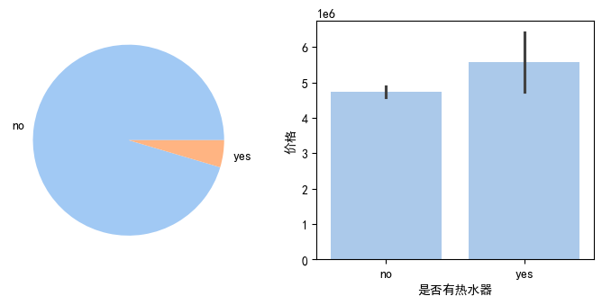

```python
figure, axes = plt.subplots(1, 2)
hotwaterheating_count = df4['是否有热水器'].value_counts()
hotwaterheating_label = hotwaterheating_count.index
axes[0].pie(hotwaterheating_count, labels=hotwaterheating_label)
sns.barplot(df4, x='是否有热水器', y='价格', ax=axes[1])
plt.show()
```

此数据集中房子绝大部分没有热水器。

从平均房价与热水器之间的柱状图来看，有热水器的的房子价格也相应高。

**是否有空调与房价**

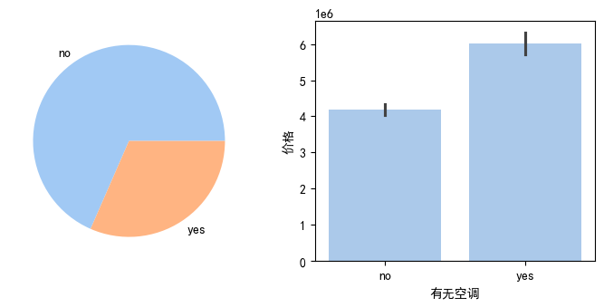

```python
figure, axes = plt.subplots(1, 2)
airconditioning_count = df4['有无空调'].value_counts()
airconditioning_label = hotwaterheating_count.index
axes[0].pie(airconditioning_count, labels=airconditioning_label)
sns.barplot(df4, x='有无空调', y='价格', ax=axes[1])
plt.show()
```

此数据集中更多的房子没有空调。

从平均房价与空调之间的柱状图来看，有空调的的房子价格也相应高。

**是否位于城市首选社区与房价**

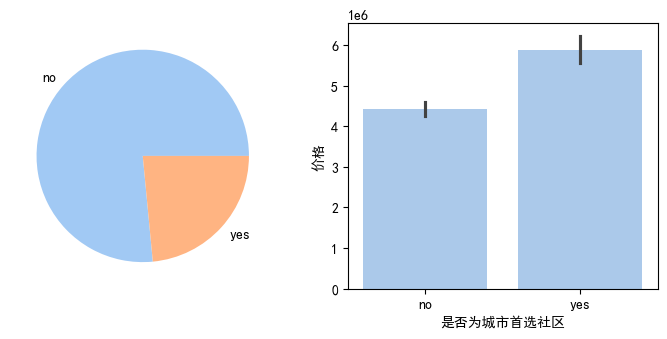

```python
figure, axes = plt.subplots(1, 2)
prefarea_count = df4['是否为城市首选社区'].value_counts()
prefarea_label = prefarea_count.index
axes[0].pie(prefarea_count, labels=prefarea_label)
sns.barplot(df4, x='是否为城市首选社区', y='价格', ax=axes[1])
plt.show()
```

此数据集中大部分房子不在城市首选社区。

从平均房价与城市首选社区之间的柱状图来看，在城市首选社区的的房子价格也相应高。

**装修状态与房价**

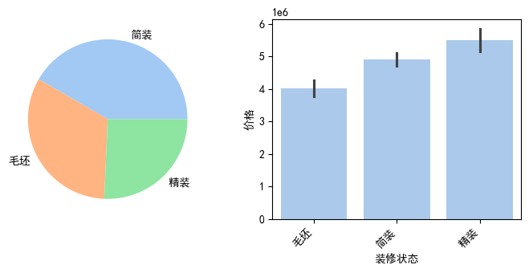

```python
figure, axes = plt.subplots(1,2)
furnishingstatus_count = df4['装修状态'].value_counts()
furnishingstatus_label = furnishingstatus_count.index
axes[0].pie(furnishingstatus_count, labels=furnishingstatus_label)
sns.barplot(df4, x='装修状态', y='价格', ax=axes[1])
axes[1].set_xticklabels(axes[1].get_xticklabels(), rotation=45, horizontalalignment='right')
plt.show()
```

此数据集中简装和毛坯的房子较多，1/4左右房子为精装。

从平均房价与装修状态之间的柱状图来看，精装的房子价格高于简装，简装高于毛坯。

## 模块三：线性回归模型建立

### 分析数据

```python
#引入线性回归模块
import statsmodels.api as sm
```

```python
df5 = df4.copy()
df5
```

|  | 价格 | 面积 | 卧室数量 | 浴室数量 | 楼层数 | 是否位于主干道 | 有无客房 | 有无地下室 | 是否有热水器 | 有无空调 | 车库数量 | 是否为城市首选社区 | 装修状态 |
| --- | --- | --- | --- | --- | --- | --- | --- | --- | --- | --- | --- | --- | --- |
| 0 | 13300000 | 689.318 | 4 | 2 | 3 | yes | no | no | no | yes | 2 | yes | 精装 |
| 1 | 12250000 | 832.384 | 4 | 4 | 4 | yes | no | no | no | yes | 3 | no | 精装 |
| 2 | 12250000 | 925.284 | 3 | 2 | 2 | yes | no | yes | no | no | 2 | yes | 简装 |
| 3 | 12215000 | 696.750 | 4 | 2 | 2 | yes | no | yes | no | yes | 3 | yes | 精装 |
| 4 | 11410000 | 689.318 | 4 | 1 | 2 | yes | yes | yes | no | yes | 2 | no | 精装 |
| ... | ... | ... | ... | ... | ... | ... | ... | ... | ... | ... | ... | ... | ... |
| 540 | 1820000 | 278.700 | 2 | 1 | 1 | yes | no | yes | no | no | 2 | no | 毛坯 |
| 541 | 1767150 | 222.960 | 3 | 1 | 1 | no | no | no | no | no | 0 | no | 简装 |
| 542 | 1750000 | 336.298 | 2 | 1 | 1 | yes | no | no | no | no | 0 | no | 毛坯 |
| 543 | 1750000 | 270.339 | 3 | 1 | 1 | no | no | no | no | no | 0 | no | 精装 |
| 544 | 1750000 | 357.665 | 3 | 1 | 2 | yes | no | no | no | no | 0 | no | 毛坯 |

545 rows × 13 columns

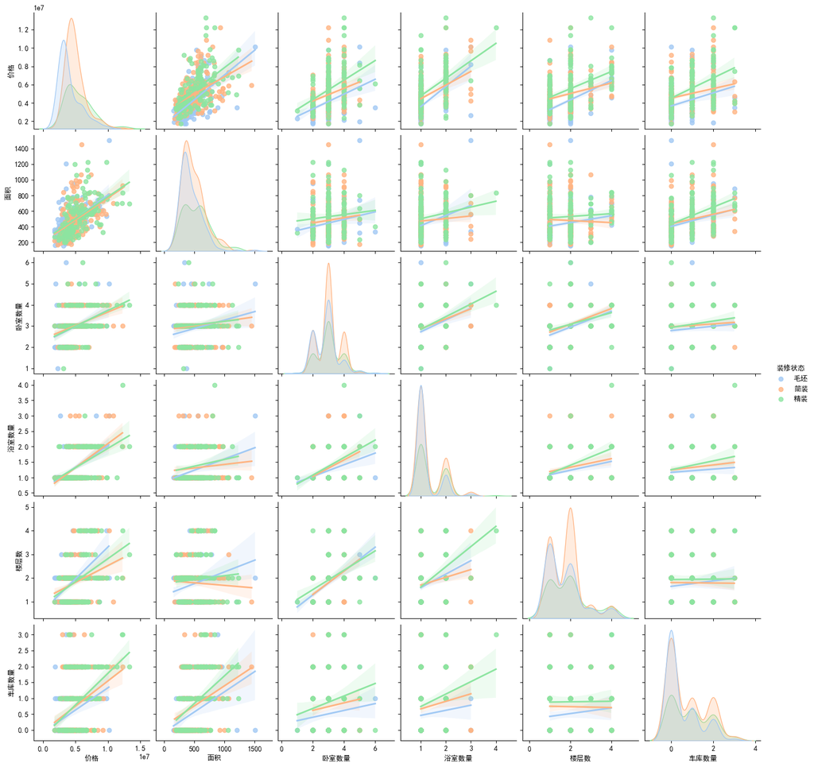

```python
sns.pairplot(df5, hue="装修状态", kind="reg")
plt.show()
```

将分类变量转换为虚拟变量，否则无法建立线性回归模型

```python
df5 = pd.get_dummies(df5, drop_first=True, columns=['是否位于主干道','有无客房','有无地下室','是否有热水器',
                                                    '有无空调','是否为城市首选社区','装修状态'], dtype = int)
df5
```

|  | 价格 | 面积 | 卧室数量 | 浴室数量 | 楼层数 | 车库数量 | 是否位于主干道_yes | 有无客房_yes | 有无地下室_yes | 是否有热水器_yes | 有无空调_yes | 是否为城市首选社区_yes | 装修状态_简装 | 装修状态_精装 |
| --- | --- | --- | --- | --- | --- | --- | --- | --- | --- | --- | --- | --- | --- | --- |
| 0 | 13300000 | 689.318 | 4 | 2 | 3 | 2 | 1 | 0 | 0 | 0 | 1 | 1 | 0 | 1 |
| 1 | 12250000 | 832.384 | 4 | 4 | 4 | 3 | 1 | 0 | 0 | 0 | 1 | 0 | 0 | 1 |
| 2 | 12250000 | 925.284 | 3 | 2 | 2 | 2 | 1 | 0 | 1 | 0 | 0 | 1 | 1 | 0 |
| 3 | 12215000 | 696.750 | 4 | 2 | 2 | 3 | 1 | 0 | 1 | 0 | 1 | 1 | 0 | 1 |
| 4 | 11410000 | 689.318 | 4 | 1 | 2 | 2 | 1 | 1 | 1 | 0 | 1 | 0 | 0 | 1 |
| ... | ... | ... | ... | ... | ... | ... | ... | ... | ... | ... | ... | ... | ... | ... |
| 540 | 1820000 | 278.700 | 2 | 1 | 1 | 2 | 1 | 0 | 1 | 0 | 0 | 0 | 0 | 0 |
| 541 | 1767150 | 222.960 | 3 | 1 | 1 | 0 | 0 | 0 | 0 | 0 | 0 | 0 | 1 | 0 |
| 542 | 1750000 | 336.298 | 2 | 1 | 1 | 0 | 1 | 0 | 0 | 0 | 0 | 0 | 0 | 0 |
| 543 | 1750000 | 270.339 | 3 | 1 | 1 | 0 | 0 | 0 | 0 | 0 | 0 | 0 | 0 | 1 |
| 544 | 1750000 | 357.665 | 3 | 1 | 2 | 0 | 1 | 0 | 0 | 0 | 0 | 0 | 0 | 0 |

545 rows × 14 columns

```python
#因变量
y = df5["价格"]
```

```python
#自变量
X = df5.drop("价格", axis = 1)
```

[output not shown]

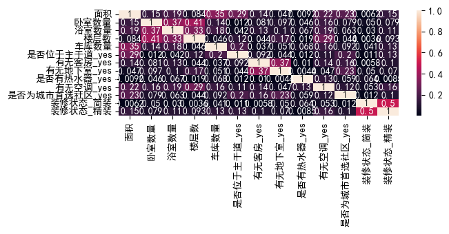

```python
sns.heatmap(X.corr().abs(), annot=True)
plt.plot()
```

排除共线性干扰

```python
#一般我们认为，当相关系数的绝对值大于0.8的时候，可能导致严重共线性，所以我们检查的时候，找绝对值大于0.8的值即可
X.corr().abs() > 0.8
```

|  | 面积 | 卧室数量 | 浴室数量 | 楼层数 | 车库数量 | 是否位于主干道_yes | 有无客房_yes | 有无地下室_yes | 是否有热水器_yes | 有无空调_yes | 是否为城市首选社区_yes | 装修状态_简装 | 装修状态_精装 |
| --- | --- | --- | --- | --- | --- | --- | --- | --- | --- | --- | --- | --- | --- |
| 面积 | True | False | False | False | False | False | False | False | False | False | False | False | False |
| 卧室数量 | False | True | False | False | False | False | False | False | False | False | False | False | False |
| 浴室数量 | False | False | True | False | False | False | False | False | False | False | False | False | False |
| 楼层数 | False | False | False | True | False | False | False | False | False | False | False | False | False |
| 车库数量 | False | False | False | False | True | False | False | False | False | False | False | False | False |
| 是否位于主干道_yes | False | False | False | False | False | True | False | False | False | False | False | False | False |
| 有无客房_yes | False | False | False | False | False | False | True | False | False | False | False | False | False |
| 有无地下室_yes | False | False | False | False | False | False | False | True | False | False | False | False | False |
| 是否有热水器_yes | False | False | False | False | False | False | False | False | True | False | False | False | False |
| 有无空调_yes | False | False | False | False | False | False | False | False | False | True | False | False | False |
| 是否为城市首选社区_yes | False | False | False | False | False | False | False | False | False | False | True | False | False |
| 装修状态_简装 | False | False | False | False | False | False | False | False | False | False | False | True | False |
| 装修状态_精装 | False | False | False | False | False | False | False | False | False | False | False | False | True |

从以上输出来看，不同变量之间相关系数的绝对值均小于或等于0.8

```python
#给模型的线性方程添加截距
X = sm.add_constant(X)
X
```

|  | const | 面积 | 卧室数量 | 浴室数量 | 楼层数 | 车库数量 | 是否位于主干道_yes | 有无客房_yes | 有无地下室_yes | 是否有热水器_yes | 有无空调_yes | 是否为城市首选社区_yes | 装修状态_简装 | 装修状态_精装 |
| --- | --- | --- | --- | --- | --- | --- | --- | --- | --- | --- | --- | --- | --- | --- |
| 0 | 1.0 | 689.318 | 4 | 2 | 3 | 2 | 1 | 0 | 0 | 0 | 1 | 1 | 0 | 1 |
| 1 | 1.0 | 832.384 | 4 | 4 | 4 | 3 | 1 | 0 | 0 | 0 | 1 | 0 | 0 | 1 |
| 2 | 1.0 | 925.284 | 3 | 2 | 2 | 2 | 1 | 0 | 1 | 0 | 0 | 1 | 1 | 0 |
| 3 | 1.0 | 696.750 | 4 | 2 | 2 | 3 | 1 | 0 | 1 | 0 | 1 | 1 | 0 | 1 |
| 4 | 1.0 | 689.318 | 4 | 1 | 2 | 2 | 1 | 1 | 1 | 0 | 1 | 0 | 0 | 1 |
| ... | ... | ... | ... | ... | ... | ... | ... | ... | ... | ... | ... | ... | ... | ... |
| 540 | 1.0 | 278.700 | 2 | 1 | 1 | 2 | 1 | 0 | 1 | 0 | 0 | 0 | 0 | 0 |
| 541 | 1.0 | 222.960 | 3 | 1 | 1 | 0 | 0 | 0 | 0 | 0 | 0 | 0 | 1 | 0 |
| 542 | 1.0 | 336.298 | 2 | 1 | 1 | 0 | 1 | 0 | 0 | 0 | 0 | 0 | 0 | 0 |
| 543 | 1.0 | 270.339 | 3 | 1 | 1 | 0 | 0 | 0 | 0 | 0 | 0 | 0 | 0 | 1 |
| 544 | 1.0 | 357.665 | 3 | 1 | 2 | 0 | 1 | 0 | 0 | 0 | 0 | 0 | 0 | 0 |

545 rows × 14 columns

```python
#利用最小二乘法来得到线性回归模型的参数值
model = sm.OLS(y, X).fit()
```

```python
#查看模型结果，使用summary方法来获得总结信息
model.summary()
```

OLS Regression Results

| Dep. Variable: | 价格 | R-squared: | 0.682 |
| --- | --- | --- | --- |
| Model: | OLS | Adj. R-squared: | 0.674 |
| Method: | Least Squares | F-statistic: | 87.52 |
| Date: | Fri, 09 May 2025 | Prob (F-statistic): | 9.07e-123 |
| Time: | 14:06:18 | Log-Likelihood: | -8331.5 |
| No. Observations: | 545 | AIC: | 1.669e+04 |
| Df Residuals: | 531 | BIC: | 1.675e+04 |
| Df Model: | 13 |  |  |
| Covariance Type: | nonrobust |  |  |

|  | coef | std err | t | P>\|t\| | [0.025 | 0.975] |
| --- | --- | --- | --- | --- | --- | --- |
| const | -3.685e+05 | 2.38e+05 | -1.549 | 0.122 | -8.36e+05 | 9.87e+04 |
| 面积 | 2627.9805 | 261.451 | 10.052 | 0.000 | 2114.375 | 3141.586 |
| 卧室数量 | 1.148e+05 | 7.26e+04 | 1.581 | 0.114 | -2.78e+04 | 2.57e+05 |
| 浴室数量 | 9.877e+05 | 1.03e+05 | 9.555 | 0.000 | 7.85e+05 | 1.19e+06 |
| 楼层数 | 4.508e+05 | 6.42e+04 | 7.026 | 0.000 | 3.25e+05 | 5.77e+05 |
| 车库数量 | 2.771e+05 | 5.85e+04 | 4.735 | 0.000 | 1.62e+05 | 3.92e+05 |
| 是否位于主干道_yes | 4.213e+05 | 1.42e+05 | 2.962 | 0.003 | 1.42e+05 | 7.01e+05 |
| 有无客房_yes | 3.005e+05 | 1.32e+05 | 2.282 | 0.023 | 4.18e+04 | 5.59e+05 |
| 有无地下室_yes | 3.501e+05 | 1.1e+05 | 3.175 | 0.002 | 1.33e+05 | 5.67e+05 |
| 是否有热水器_yes | 8.554e+05 | 2.23e+05 | 3.833 | 0.000 | 4.17e+05 | 1.29e+06 |
| 有无空调_yes | 8.65e+05 | 1.08e+05 | 7.983 | 0.000 | 6.52e+05 | 1.08e+06 |
| 是否为城市首选社区_yes | 6.515e+05 | 1.16e+05 | 5.632 | 0.000 | 4.24e+05 | 8.79e+05 |
| 装修状态_简装 | 3.649e+05 | 1.09e+05 | 3.342 | 0.001 | 1.5e+05 | 5.79e+05 |
| 装修状态_精装 | 4.112e+05 | 1.26e+05 | 3.258 | 0.001 | 1.63e+05 | 6.59e+05 |

| Omnibus: | 97.909 | Durbin-Watson: | 1.209 |
| --- | --- | --- | --- |
| Prob(Omnibus): | 0.000 | Jarque-Bera (JB): | 258.281 |
| Skew: | 0.895 | Prob(JB): | 8.22e-57 |
| Kurtosis: | 5.859 | Cond. No. | 2.87e+03 |

Notes:  
[1] Standard Errors assume that the covariance matrix of the errors is correctly specified.  
[2] The condition number is large, 2.87e+03. This might indicate that there are  
strong multicollinearity or other numerical problems.

```python
X = X.drop(['const', '卧室数量', '装修状态_简装'], axis=1)
```

```python
model = sm.OLS(y, X).fit()
```

```python
model.summary()
```

OLS Regression Results

| Dep. Variable: | 价格 | R-squared (uncentered): | 0.956 |
| --- | --- | --- | --- |
| Model: | OLS | Adj. R-squared (uncentered): | 0.956 |
| Method: | Least Squares | F-statistic: | 1067. |
| Date: | Fri, 09 May 2025 | Prob (F-statistic): | 0.00 |
| Time: | 14:06:18 | Log-Likelihood: | -8338.7 |
| No. Observations: | 545 | AIC: | 1.670e+04 |
| Df Residuals: | 534 | BIC: | 1.675e+04 |
| Df Model: | 11 |  |  |
| Covariance Type: | nonrobust |  |  |

|  | coef | std err | t | P>\|t\| | [0.025 | 0.975] |
| --- | --- | --- | --- | --- | --- | --- |
| 面积 | 2672.8349 | 244.550 | 10.930 | 0.000 | 2192.438 | 3153.232 |
| 浴室数量 | 1.034e+06 | 9.32e+04 | 11.093 | 0.000 | 8.51e+05 | 1.22e+06 |
| 楼层数 | 4.909e+05 | 5.76e+04 | 8.527 | 0.000 | 3.78e+05 | 6.04e+05 |
| 车库数量 | 3.006e+05 | 5.84e+04 | 5.145 | 0.000 | 1.86e+05 | 4.15e+05 |
| 是否位于主干道_yes | 4.099e+05 | 1.28e+05 | 3.203 | 0.001 | 1.59e+05 | 6.61e+05 |
| 有无客房_yes | 3.043e+05 | 1.32e+05 | 2.298 | 0.022 | 4.42e+04 | 5.64e+05 |
| 有无地下室_yes | 4.004e+05 | 1.08e+05 | 3.717 | 0.000 | 1.89e+05 | 6.12e+05 |
| 是否有热水器_yes | 9.056e+05 | 2.25e+05 | 4.024 | 0.000 | 4.64e+05 | 1.35e+06 |
| 有无空调_yes | 8.618e+05 | 1.09e+05 | 7.925 | 0.000 | 6.48e+05 | 1.08e+06 |
| 是否为城市首选社区_yes | 6.564e+05 | 1.16e+05 | 5.647 | 0.000 | 4.28e+05 | 8.85e+05 |
| 装修状态_精装 | 1.948e+05 | 1.09e+05 | 1.786 | 0.075 | -1.95e+04 | 4.09e+05 |

| Omnibus: | 98.051 | Durbin-Watson: | 1.187 |
| --- | --- | --- | --- |
| Prob(Omnibus): | 0.000 | Jarque-Bera (JB): | 263.737 |
| Skew: | 0.889 | Prob(JB): | 5.37e-58 |
| Kurtosis: | 5.907 | Cond. No. | 2.54e+03 |

Notes:  
[1] R² is computed without centering (uncentered) since the model does not contain a constant.  
[2] Standard Errors assume that the covariance matrix of the errors is correctly specified.  
[3] The condition number is large, 2.54e+03. This might indicate that there are  
strong multicollinearity or other numerical problems.

## 模块四：房价预测

根据各个自变量在线性回归方程中的系数来看，模型预测以下因素的增加（或存在）会显著增加房屋价格：房屋面积、厕所数、楼层数、车库容量、位于主路、有客房、有地下室、有热水器、有空调、位于城市首选社区。

```python
# 要预测房价的房屋的信息：
# 面积为200平方米，有3个卧室、1个厕所，总共2层，不位于主路，无客人房，带地下室，有热水器，有空调，车位数为1，不是城市首选社区，简装修
```

```python
yuce = pd.DataFrame({'area': [200], '卧室数量': [3], '浴室数量': [1],
                                 '楼层数': [2], '是否位于主干道': ['no'], '有无客房': ['no'],
                                 '有无地下室': ['yes'], '是否有热水器': ['yes'],
                                 '有无空调': ['yes'], '车库数量': 1, '是否为城市首选社区': ['no'],
                                 '装修状态': ['简装']})
yuce
```

|  | area | 卧室数量 | 浴室数量 | 楼层数 | 是否位于主干道 | 有无客房 | 有无地下室 | 是否有热水器 | 有无空调 | 车库数量 | 是否为城市首选社区 | 装修状态 |
| --- | --- | --- | --- | --- | --- | --- | --- | --- | --- | --- | --- | --- |
| 0 | 200 | 3 | 1 | 2 | no | no | yes | yes | yes | 1 | no | 简装 |

把分类变量的类型转换为Category,让程序知道所有可能的分类值,我们需要确保引入虚拟变量的时候，不会漏掉某个或某些分类

```python
yuce['是否位于主干道'] = pd.Categorical(yuce['是否位于主干道'], categories=['no', 'yes'])
yuce['有无客房'] = pd.Categorical(yuce['有无客房'], categories=['no', 'yes'])
yuce['有无地下室'] = pd.Categorical(yuce['有无地下室'], categories=['no', 'yes'])
yuce['是否有热水器'] = pd.Categorical(yuce['是否有热水器'], categories=['no', 'yes'])
yuce['有无空调'] = pd.Categorical(yuce['有无空调'], categories=['no', 'yes'])
yuce['是否为城市首选社区'] = pd.Categorical(yuce['是否为城市首选社区'], categories=['no', 'yes'])
yuce['装修状态'] = pd.Categorical(yuce['装修状态'], categories=['精装', '简装', '毛坯'])
```

```python
yuce = pd.get_dummies(yuce, drop_first=True,
                                  columns=['是否位于主干道', '有无客房',
                                           '有无地下室', '是否有热水器',
                                           '有无空调','是否为城市首选社区',
                                           '装修状态'], dtype=int)
yuce.head()
```

|  | area | 卧室数量 | 浴室数量 | 楼层数 | 车库数量 | 是否位于主干道_yes | 有无客房_yes | 有无地下室_yes | 是否有热水器_yes | 有无空调_yes | 是否为城市首选社区_yes | 装修状态_简装 | 装修状态_毛坯 |
| --- | --- | --- | --- | --- | --- | --- | --- | --- | --- | --- | --- | --- | --- |
| 0 | 200 | 3 | 1 | 2 | 1 | 0 | 0 | 1 | 1 | 1 | 0 | 1 | 0 |

```python
yuce = yuce.drop(['卧室数量', '装修状态_简装'], axis=1)
```

### 调用线性回归模型的predict方法，获得预测价格

```python
predicted_value = model.predict(yuce)
predicted_value
```

```
0    5.019251e+06
dtype: float64
```